# Regressão Logística Binária

Paulo 04 de junho de 2026

- 1. Introdução e Motivação
  - 1.1 Por que não usar regressão linear?
  - 1.2 Aplicações típicas
  - 1.3 Fluxo da análise
- 2. O Modelo Logístico
  - 2.1 A função sigmoide
  - 2.2 A transformação logit e os odds
    - Interpretação dos coeficientes via Odds Ratio
- 3. Estimação por Máxima Verossimilhança
  - 3.1 O princípio
  - 3.2 A função de verossimilhança
  - 3.3 A log-verossimilhança
  - 3.4 Exemplo: preferência por café
  - 3.5 Log-verossimilhança com preditoras (modelo geral)
- 4. Avaliação do Modelo
  - 4.1 Pseudo-R² de McFadden
  - 4.2 Acurácia e taxa de erro aparente
  - 4.3 Matriz de confusão
  - 4.4 Curva ROC e AUC
- 5. Testes de Hipóteses
  - 5.1 Teste da razão de verossimilhanças (TRV) — modelo global
  - 5.2 Teste de Wald — coeficientes individuais
- 6. Previsão com o Modelo
- 7. Implementação em R
  - 7.1 Pacotes
  - 7.2 Configuração e importação dos dados
  - 7.3 Análise exploratória
  - 7.4 Divisão treino/teste e ajuste do modelo
  - 7.5 Coeficientes e odds ratios
  - 7.6 Pseudo-R² de McFadden
  - 7.7 Teste da razão de verossimilhanças
  - 7.8 Teste de Wald
  - 7.9 Previsão e avaliação no conjunto de teste
  - 7.10 Visualizações: matriz de confusão e curva ROC
  - 7.11 Previsão para nova observação
- 8. Implementação em Python
  - 8.1 Dependências
  - 8.2 Configuração e importação dos dados
  - 8.3 Análise exploratória
  - 8.4 Divisão treino/teste e ajuste do modelo
  - 8.5 Coeficientes e odds ratios
  - 8.6 Pseudo-R² de McFadden
  - 8.7 Teste da razão de verossimilhanças
  - 8.8 Teste de Wald
  - 8.9 Previsão e avaliação no conjunto de teste
  - 8.10 Visualizações: matriz de confusão e curva ROC
  - 8.11 Previsão para nova observação
- 9. Comparativo R vs Python
- 10. Checklist da Análise Completa
- 11. Referências

> **Sobre este tutorial**  
> Cobertura completa da regressão logística binária: da motivação matemática até a implementação prática em **R** e **Python**. O código aceita qualquer arquivo `.csv` — basta ajustar o bloco de configuração indicado em cada seção.  
> Baseado em notas de aula revisadas, com formalismo estatístico e conteúdos complementares ausentes no manuscrito original.

# 1. Introdução e Motivação

## 1.1 Por que não usar regressão linear?

Quando a variável resposta $y$ é **binária** — assume apenas os valores $0$ (fracasso, ausência, não-evento) e $1$ (sucesso, presença, evento) — a regressão linear ordinária apresenta problemas fundamentais:

| Problema | Descrição |
| --- | --- |
| Previsões fora de $$0,1$$ | $\hat{y} = \mathbf{x}^\top\boldsymbol{\beta}$ pode assumir qualquer valor real, resultando em “probabilidades” negativas ou maiores que 1 |
| **Heterocedasticidade estrutural** | A variância de $y \sim \text{Bernoulli}(p)$ é $p(1-p)$, que varia com $p$, violando a homocedasticidade |
| **Distribuição dos resíduos** | Os resíduos não seguem distribuição normal, invalidando os testes da regressão linear |

A solução é modelar diretamente a **probabilidade condicional** $P(Y=1 \mid \mathbf{x})$ por meio de uma função que mapeie $(-\infty, +\infty) \to (0, 1)$. A função escolhida é a **sigmoide logística**.

## 1.2 Aplicações típicas

- **Medicina:** diagnóstico (doente/saudável), presença de doença (sim/não)
- **Finanças:** inadimplência (sim/não), fraude (sim/não)
- **Marketing:** conversão de cliente (compra/não compra), *churn* (cancela/permanece)
- **NLP:** detecção de spam (spam/não-spam), sentimento (positivo/negativo)
- **Biologia:** sobrevivência de espécie (sobrevive/extingue)

## 1.3 Fluxo da análise

O pipeline completo de uma análise de regressão logística binária:

```
Dados .csv
    │
    ▼
① Exploração (dispersão, boxplots, balanço de classes)
    │
    ▼
② Estimação do modelo (Máxima Verossimilhança)
    │
    ▼
③ Avaliação da acurácia (pseudo-R², acurácia, AUC-ROC)
    │
    ▼
④ Testes de hipóteses (TRV global + Wald individual)
    │
    ▼
⑤ Previsão para novas observações
```

# 2. O Modelo Logístico

## 2.1 A função sigmoide

A equação central do modelo é:

$$\boxed{\hat{y} = P(Y = 1 \mid
\mathbf{x}) = \frac{1}{1 + e^{-z}}, \quad z = a_1 x_1 + a_2 x_2 + \cdots
+ a_p x_p + b}$$

onde:

| Símbolo | Nome | Descrição |
| --- | --- | --- |
| $x_1, \ldots, x_p$ | Variáveis preditoras | Características observadas |
| $a_1, \ldots, a_p$ | Coeficientes de regressão | Parâmetros estimados pelo modelo |
| $b$ | Intercepto | Parâmetro constante (viés) |
| $z$ | Log-odds (logit) | Combinação linear das preditoras |
| $\hat{y}$ | Probabilidade predita | $P(Y=1 \mid \mathbf{x}) \in (0,1)$ |

**Propriedade fundamental:** independentemente do valor de $z$, $0 < \hat{y} < 1$ sempre. O modelo nunca produz uma probabilidade inválida.

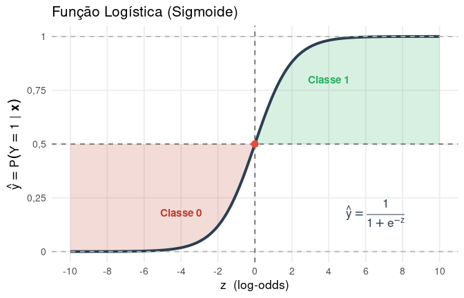

Figura 1. Função Sigmoide: mapeamento do espaço real no intervalo (0,1). A região verde indica P ≥ 0,5 (classificado como 1); a vermelha, P < 0,5 (classificado como 0).

```r
library(ggplot2)
library(dplyr)
library(pROC)
library(caret)
library(gridExtra)

z_vals <- seq(-10, 10, length.out = 600)
sig_df <- data.frame(z = z_vals, y = 1 / (1 + exp(-z_vals)))

ggplot(sig_df, aes(x = z, y = y)) +
  geom_ribbon(data = filter(sig_df, y >= 0.5),
              aes(ymin = 0.5, ymax = y), fill = "#27AE60", alpha = 0.18) +
  geom_ribbon(data = filter(sig_df, y < 0.5),
              aes(ymin = y, ymax = 0.5), fill = "#C0392B", alpha = 0.18) +
  geom_line(color = "#2C3E50", size = 1.4) +
  geom_hline(yintercept = c(0, 0.5, 1), linetype = "dashed",
             color = c("gray70","gray40","gray70"), size = 0.6) +
  geom_vline(xintercept = 0, linetype = "dashed", color = "gray40", size = 0.6) +
  geom_point(data = data.frame(z = 0, y = 0.5),
             aes(x = z, y = y), color = "#E74C3C", size = 3) +
  annotate("text", x = 6.5, y = 0.18,
           label = "hat(y) == frac(1, 1 + e^{-z})",
           parse = TRUE, size = 4.5, color = "#2C3E50") +
  annotate("text", x = 4, y = 0.80, label = "Classe 1", color = "#27AE60",
           fontface = "bold", size = 4) +
  annotate("text", x = -4, y = 0.18, label = "Classe 0", color = "#C0392B",
           fontface = "bold", size = 4) +
  scale_y_continuous(breaks = c(0, 0.25, 0.5, 0.75, 1),
                     labels = c("0","0,25","0,5","0,75","1")) +
  scale_x_continuous(breaks = seq(-10, 10, 2)) +
  labs(x = "z  (log-odds)", y = expression(hat(y) == P(Y == 1 ~ "|" ~ bold(x))),
       title = "Função Logística (Sigmoide)") +
  theme_minimal(base_size = 13) +
  theme(panel.grid.minor = element_blank())
```

## 2.2 A transformação logit e os odds

Invertendo a função sigmoide:

$$\underbrace{\log_e\!\left(\frac{p}{1-p}\right)}_{\text{logit}(p)}
= z = a_1 x_1 + \cdots + a_p x_p + b$$

O termo $\dfrac{p}{1-p}$ é a **razão de chances** (*odds*): razão entre a probabilidade de ocorrência e de não-ocorrência do evento. A transformação logit lineariza a relação entre as preditoras e os odds do evento, que é a base para interpretar os coeficientes.

### Interpretação dos coeficientes via Odds Ratio

$$OR_i = e^{a_i}$$

| Situação | Interpretação |
| --- | --- |
| $a_i > 0$ $\Rightarrow$ $OR_i > 1$ | Aumento de 1 unidade em $x_i$ **multiplica** os odds por $e^{a_i}$ |
| $a_i < 0$ $\Rightarrow$ $OR_i < 1$ | Aumento de 1 unidade em $x_i$ **reduz** os odds por fator $e^{a_i}$ |
| $a_i = 0$ $\Rightarrow$ $OR_i = 1$ | $x_i$ não tem efeito sobre os odds do evento |

> **Exemplo numérico:** se $a_1 = 2{,}44$, então $OR_1 = e^{2,44} \approx 11{,}47$. Um aumento de 1 unidade em $x_1$ eleva os odds do evento em **1047%**, mantidas as demais variáveis constantes.

# 3. Estimação por Máxima Verossimilhança

## 3.1 O princípio

A **Máxima Verossimilhança** (MV) encontra os valores de $\boldsymbol{a}$ e $b$ que **maximizam a probabilidade de se observar exatamente os dados coletados**, dada a estrutura do modelo.

## 3.2 A função de verossimilhança

Para $n$ observações independentes, com $y_i \in \{0,1\}$, cada observação segue uma distribuição de Bernoulli com parâmetro $\hat{y}_i$. A verossimilhança conjunta é:

$$\mathcal{L}(\boldsymbol{a}, b) =
\prod_{i=1}^{n} \hat{y}_i^{\;y_i} \cdot (1 -
\hat{y}_i)^{1-y_i}$$

Cada fator contribui com: - $\hat{y}_i$ quando $y_i = 1$ (probabilidade prevista de sucesso)  
- $(1 - \hat{y}_i)$ quando $y_i = 0$ (probabilidade prevista de fracasso)

## 3.3 A log-verossimilhança

Para evitar *underflow* numérico e transformar o produto em soma, maximiza-se o logaritmo natural:

$$\boxed{L(\boldsymbol{a}, b) =
\sum_{i=1}^{n}\left[\, y_i \log_e(\hat{y}_i) +
(1-y_i)\log_e(1-\hat{y}_i) \,\right]}$$

**Propriedades:**

- $L \leq 0$ sempre, pois $\log_e(\hat{y}_i) \leq 0$ para $\hat{y}_i \in (0,1)$
- $L = 0$ somente quando o modelo classifica perfeitamente todos os pontos
- Maximizar $L$ equivale a minimizar a **entropia cruzada binária**, função de perda usada em redes neurais para classificação binária

## 3.4 Exemplo: preferência por café

Pesquisa com 10 pessoas, das quais 7 responderam “Sim” e 3, “Não”. Parâmetro a estimar: $p$ (proporção que gosta de café).

**Verossimilhança** (desconsiderando combinatórias — não afetam o maximizador):
$$\mathcal{L}(p) = p^7
\cdot (1-p)^3$$

**Log-verossimilhança:**
$$L(p) = 7\log_e(p) + 3\log_e(1-p)$$

**Condição de 1ª ordem** (ponto crítico):
$$\frac{dL}{dp} = \frac{7}{p} - \frac{3}{1-p} = 0
\;\implies\; 7(1-p) = 3p \;\implies\; \hat{p} = \frac{7}{10} =
0{,}7$$

**Condição de 2ª ordem** (verificação de máximo):
$$\frac{d^2L}{dp^2} = -\frac{7}{p^2} -
\frac{3}{(1-p)^2} < 0 \quad \forall\, p \in (0,1)$$

Como a segunda derivada é estritamente negativa, $\hat{p} = 0{,}7$ é um **máximo global** — coincide, como esperado, com a proporção amostral.

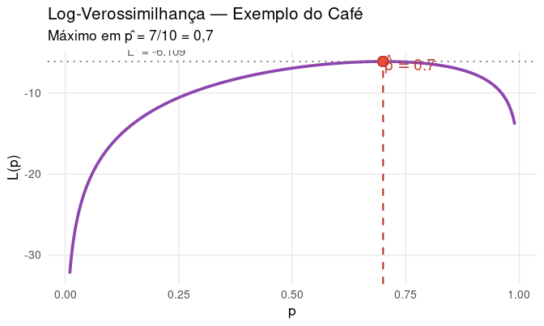

Figura 2. Log-verossimilhança para o exemplo do café. O máximo global em p = 0,7 coincide com a proporção amostral.

```r
p_seq  <- seq(0.01, 0.99, length.out = 500)
L_cafe <- 7 * log(p_seq) + 3 * log(1 - p_seq)
p_hat  <- 7 / 10
L_hat  <- 7 * log(p_hat) + 3 * log(1 - p_hat)

mv_df  <- data.frame(p = p_seq, L = L_cafe)

ggplot(mv_df, aes(x = p, y = L)) +
  geom_line(color = "#8E44AD", size = 1.3) +
  geom_vline(xintercept = p_hat, linetype = "dashed",
             color = "#C0392B", size = 0.8) +
  geom_hline(yintercept = L_hat, linetype = "dotted",
             color = "gray50", size = 0.7) +
  geom_point(aes(x = p_hat, y = L_hat),
             color = "#C0392B", size = 4, shape = 21,
             fill = "#E74C3C") +
  annotate("text", x = 0.76, y = L_hat - 0.3,
           label = expression(hat(p) == 0.7),
           color = "#C0392B", size = 5, fontface = "bold") +
  annotate("text", x = 0.20, y = L_hat,
           label = paste0("L* = ", round(L_hat, 3)),
           color = "gray40", size = 4, vjust = -0.6) +
  labs(x = "p", y = "L(p)",
       title = "Log-Verossimilhança — Exemplo do Café",
       subtitle = "Máximo em p̂ = 7/10 = 0,7") +
  theme_minimal(base_size = 13) +
  theme(panel.grid.minor = element_blank())
```

## 3.5 Log-verossimilhança com preditoras (modelo geral)

Substituindo $\hat{y}_i = \sigma(z_i)$:

$$L(\boldsymbol{a}, b) = \sum_{i=1}^{n}
\left[\, y_i \log_e\!\left(\frac{1}{1+e^{-z_i}}\right) +
(1-y_i)\log_e\!\left(\frac{e^{-z_i}}{1+e^{-z_i}}\right)
\,\right]$$

**Não existe solução analítica fechada.** Os coeficientes são estimados por algoritmos de otimização iterativa:

| Algoritmo | Descrição | Implementação |
| --- | --- | --- |
| Newton-Raphson (IRLS) | Usa gradiente e hessiana exata; converge rapidamente | `glm()` no R |
| BFGS / L-BFGS | Aproxima a hessiana; eficiente para muitas variáveis | `statsmodels`, `sklearn` |
| Gradiente Descendente | Atualização por mini-batch; escalável a Big Data | Redes neurais, TensorFlow |

# 4. Avaliação do Modelo

## 4.1 Pseudo-R² de McFadden

Na regressão logística não existe um $R^2$ com interpretação geométrica direta. O **pseudo-$R^2$ de McFadden** (1974) é a medida mais usada:

| Símbolo | Definição |
| --- | --- |
| $L^*$ | Log-verossimilhança máxima do modelo ajustado ($\leq 0$) |
| $L_0$ | Log-verossimilhança do modelo nulo (só intercepto) |
| $N_1$ | Número de sucessos ($y = 1$) |
| $N_0$ | Número de fracassos ($y = 0$) |

O denominador $L_0$ equivale à log-verossimilhança de um modelo que prevê $\hat{p} = N_1/N$ para todos — o “pior” modelo útil.

**Tabela de interpretação:**

| Valor de $R^2_{\text{McFadden}}$ | Avaliação |
| --- | --- |
| $< 0{,}20$ | Ajuste fraco |
| $0{,}20 - 0{,}40$ | Bom ajuste |
| $> 0{,}40$ | Ajuste muito bom |

> Na regressão logística, valores relativamente baixos de pseudo-$R^2$ são esperados e não indicam necessariamente um modelo ruim. Um $R^2_{\text{McFadden}} \approx 0{,}4$ em regressão logística é comparável a um $R^2 \approx 0{,}9$ em regressão linear.

## 4.2 Acurácia e taxa de erro aparente

$$\text{Acurácia} =
\frac{\text{classificações corretas}}{n}, \qquad \text{Taxa de Erro} = 1
- \text{Acurácia}$$

A **taxa de erro aparente** é calculada no conjunto de treino e tende a subestimar o erro real. O correto é calculá-la no **conjunto de teste** (dados não vistos durante o ajuste).

## 4.3 Matriz de confusão

Para um limiar de decisão $\tau$ (geralmente $0{,}5$), classifica-se:

$$\hat{y}_i = \begin{cases} 1 &
\text{se } \hat{p}_i \geq \tau \\ 0 & \text{se } \hat{p}_i < \tau
\end{cases}$$

A **matriz de confusão** cruza os valores reais com as previsões:

|  | **Predito 0** | **Predito 1** |
| --- | --- | --- |
| **Real 0** | Verdadeiro Negativo (VN) | Falso Positivo (FP) — Erro Tipo I |
| **Real 1** | Falso Negativo (FN) — Erro Tipo II | Verdadeiro Positivo (VP) |

**Métricas derivadas:**

$$\text{Sensibilidade} = \frac{VP}{VP+FN}
\qquad \text{Especificidade} = \frac{VN}{VN+FP}$$

$$\text{Precisão} = \frac{VP}{VP+FP}
\qquad \text{F1-Score} = 2\cdot\frac{\text{Precisão} \times
\text{Sensibilidade}}{\text{Precisão} +
\text{Sensibilidade}}$$

> **Escolha do limiar $\tau$:** em contextos onde falsos negativos são muito custosos (ex.: diagnóstico de câncer), adota-se $\tau < 0{,}5$ para aumentar a sensibilidade, aceitando mais falsos positivos. A curva ROC auxilia nessa escolha.

## 4.4 Curva ROC e AUC

A **Curva ROC** (*Receiver Operating Characteristic*) plota a **Sensibilidade (TPR)** versus **(1 − Especificidade) = FPR** para **todos os possíveis limiares** $\tau \in [0,1]$.

A **AUC** (*Area Under the ROC Curve*) resume o desempenho:

| AUC | Interpretação |
| --- | --- |
| $0{,}5$ | Classificador aleatório (sem poder preditivo) |
| $0{,}70 - 0{,}80$ | Desempenho aceitável |
| $0{,}80 - 0{,}90$ | Bom desempenho |
| $> 0{,}90$ | Desempenho excelente |

A AUC também pode ser interpretada como a probabilidade de que, dado um par aleatório (um positivo e um negativo), o modelo atribua maior probabilidade ao positivo: $\text{AUC} = P(\hat{p}_1 > \hat{p}_0)$.

# 5. Testes de Hipóteses

## 5.1 Teste da razão de verossimilhanças (TRV) — modelo global

Avalia se o modelo ajustado é **globalmente** significativo em relação ao modelo nulo (sem preditoras).

**Hipóteses:**
$$H_0: a_1 =
a_2 = \cdots = a_p = 0 \qquad \text{vs.} \qquad H_1: \exists\, i: a_i
\neq 0$$

**Estatística de teste:**
$$G
= 2(L^* - L_0) \;\xrightarrow{H_0}\; \chi^2_{(p)}$$

onde $p$ é o número de preditoras (graus de liberdade). Rejeita-se $H_0$ se o valor-p $< \alpha$.

**Protocolo de decisão:**

1. Definir a população de interesse
2. Enunciar $H_0$ e $H_1$
3. Escolher o TRV como teste
4. Fixar $\alpha = 0{,}05$
5. Calcular $G = 2(L^* - L_0)$
6. Obter valor-p: $P(\chi^2_{(p)} \geq G)$
7. Decisão: rejeitar $H_0$ se valor-p $< 0{,}05$; caso contrário, não rejeitar

## 5.2 Teste de Wald — coeficientes individuais

Avalia a significância de **cada coeficiente** separadamente.

**Hipóteses para o $i$-ésimo coeficiente:**
$$H_0: a_i = 0 \qquad
\text{vs.} \qquad H_1: a_i \neq 0$$

**Estatística de Wald:**
$$W_i =
\left(\frac{\hat{a}_i}{SE(\hat{a}_i)}\right)^2 \;\xrightarrow{H_0}\;
\chi^2_{(1)}$$

O erro padrão $SE(\hat{a}_i)$ é a raiz quadrada do $i$-ésimo elemento diagonal da matriz de covariância dos estimadores:

$$\widehat{\text{Var}}(\hat{\boldsymbol{a}}) =
\left(\mathbf{X}^\top \widehat{W}\, \mathbf{X}\right)^{-1}, \quad
\widehat{W} = \text{diag}\{\hat{y}_i(1-\hat{y}_i)\}$$

A estatística equivalente em escala normal é $z_i = \hat{a}_i / SE(\hat{a}_i) \sim \mathcal{N}(0,1)$, reportada como “z value” na saída do R.

**Protocolo de decisão:**

1. Definir a população
2. $H_0: a_i = 0$ e $H_1: a_i \neq 0$
3. Escolher o Teste de Wald
4. Fixar $\alpha = 0{,}05$
5. Calcular $W_i = \hat{a}_i^2 / SE(\hat{a}_i)^2$
6. Obter valor-p: $P(\chi^2_{(1)} \geq W_i)$
7. Rejeitar $H_0$ se valor-p $< 0{,}05$

# 6. Previsão com o Modelo

Com o modelo validado, a probabilidade predita para uma nova observação $\mathbf{x}^* = (x_1^*, \ldots, x_p^*)$ é:

$$\hat{p} = \frac{1}{1 + e^{-(\hat{a}_1
x_1^* + \cdots + \hat{a}_p x_p^* + \hat{b})}}$$

A classificação usa o limiar $\tau$:

$$\hat{y} = \begin{cases} 1 & \text{se
} \hat{p} \geq \tau \\ 0 & \text{se } \hat{p} < \tau
\end{cases}$$

O limiar padrão $\tau = 0{,}5$ pode ser ajustado com base na curva ROC para equilibrar sensibilidade e especificidade conforme o contexto.

# 7. Implementação em R

> **Como usar:** ajuste as **6 variáveis** do bloco `CONFIGURAÇÃO` abaixo para o seu arquivo `.csv`. Todo o restante do código funciona automaticamente. Se o arquivo não existir, dados simulados são gerados para demonstração.

## 7.1 Pacotes

```r
# Instalação automática dos pacotes ausentes
pkgs_necessarios <- c("ggplot2", "dplyr", "pROC", "caret",
                      "DescTools", "gridExtra", "knitr")
pkgs_ausentes    <- pkgs_necessarios[
  !pkgs_necessarios %in% installed.packages()[, "Package"]
]
if (length(pkgs_ausentes) > 0)
  install.packages(pkgs_ausentes, repos = "https://cran.r-project.org",
                   quiet = TRUE)

suppressPackageStartupMessages({
  library(ggplot2)
  library(dplyr)
  library(pROC)
  library(caret)
  library(DescTools)
  library(gridExtra)
  library(knitr)
})
```

## 7.2 Configuração e importação dos dados

```r
# ════════════════════════════════════════════════════════════
#  CONFIGURAÇÃO — ajuste apenas estas variáveis
# ════════════════════════════════════════════════════════════
CAMINHO_CSV       <- "dados.csv"      # caminho para o arquivo .csv
VARIAVEL_RESPOSTA <- "y"              # coluna resposta (valores 0 e 1)
VARIAVEIS_PRED    <- c("x1", "x2")   # vetor com nomes das preditoras
LIMIAR_DECISAO    <- 0.5             # limiar de classificação τ
PROPORCAO_TREINO  <- 0.70            # fração para treino
SEMENTE           <- 42              # semente para reprodutibilidade
# ════════════════════════════════════════════════════════════

# ── Geração de dados simulados (apenas se o .csv não existir) ──────────────
if (!file.exists(CAMINHO_CSV)) {
  message("Arquivo não encontrado — gerando dados simulados.")
  set.seed(SEMENTE)
  n_sim  <- 350
  x1_sim <- round(runif(n_sim, 18, 65), 1)   # ex.: idade
  x2_sim <- round(rnorm(n_sim, 50, 10),  1)   # ex.: pontuação
  z_sim  <- 0.07 * x1_sim + 0.06 * x2_sim - 7.0
  p_sim  <- 1 / (1 + exp(-z_sim))
  y_sim  <- rbinom(n_sim, 1, p_sim)
  df_sim <- data.frame(y = y_sim, x1 = x1_sim, x2 = x2_sim)
  write.csv(df_sim, CAMINHO_CSV, row.names = FALSE)
  message(sprintf("Arquivo '%s' criado com %d observações.", CAMINHO_CSV, n_sim))
}

# ── Leitura ─────────────────────────────────────────────────────────────────
raw <- read.csv(CAMINHO_CSV, stringsAsFactors = FALSE)
cat(sprintf("Dataset lido: %d linhas × %d colunas\n", nrow(raw), ncol(raw)))
```

```
#> Dataset lido: 350 linhas × 3 colunas
```

```r
cat("Colunas:", paste(names(raw), collapse = ", "), "\n")
```

```
#> Colunas: y, x1, x2
```

```r
# ── Validação das colunas configuradas ──────────────────────────────────────
cols_req     <- c(VARIAVEL_RESPOSTA, VARIAVEIS_PRED)
cols_missing <- setdiff(cols_req, names(raw))
if (length(cols_missing) > 0)
  stop("Colunas ausentes no CSV: ", paste(cols_missing, collapse = ", "),
       "\nAjuste VARIAVEL_RESPOSTA e VARIAVEIS_PRED.")

# ── Data frame de trabalho ───────────────────────────────────────────────────
dados           <- raw[, cols_req]
names(dados)[1] <- "y"
dados$y         <- as.integer(as.character(dados$y))

# Remoção de NAs
n_antes  <- nrow(dados)
dados    <- na.omit(dados)
n_depois <- nrow(dados)
if (n_antes > n_depois)
  cat(sprintf("Removidas %d linha(s) com NA.\n", n_antes - n_depois))

cat(sprintf("Observações válidas: %d\n", n_depois))
```

```
#> Observações válidas: 350
```

## 7.3 Análise exploratória

```r
N1 <- sum(dados$y == 1)
N0 <- sum(dados$y == 0)
N  <- nrow(dados)

cat(sprintf(
  "Classe 1 (sucesso):  %d  (%.1f%%)\nClasse 0 (fracasso): %d  (%.1f%%)\n",
  N1, 100 * N1 / N, N0, 100 * N0 / N
))
```

```
#> Classe 1 (sucesso):  92  (26.3%)
#> Classe 0 (fracasso): 258  (73.7%)
```

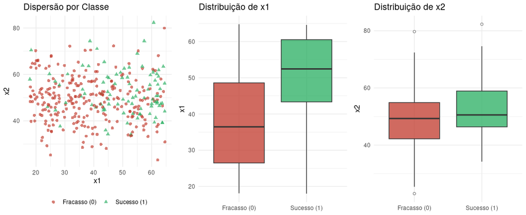

Figura 3. Esquerda: dispersão das preditoras com separação por classe. Centro e direita: distribuição de cada preditora por classe.

```r
dados$y_fator <- factor(dados$y, levels = c(0, 1),
                         labels = c("Fracasso (0)", "Sucesso (1)"))
pal <- c("Fracasso (0)" = "#C0392B", "Sucesso (1)" = "#27AE60")

# Gráfico de dispersão
p_disp <- ggplot(dados,
                 aes_string(x = VARIAVEIS_PRED[1],
                             y = if (length(VARIAVEIS_PRED) > 1) VARIAVEIS_PRED[2]
                                 else VARIAVEIS_PRED[1],
                             color = "y_fator", shape = "y_fator")) +
  geom_jitter(alpha = 0.65, size = 1.8, width = 0.25, height = 0.25) +
  scale_color_manual(values = pal) +
  scale_shape_manual(values = c("Fracasso (0)" = 16, "Sucesso (1)" = 17)) +
  labs(title = "Dispersão por Classe",
       color = NULL, shape = NULL) +
  theme_minimal(base_size = 11) +
  theme(legend.position = "bottom")

# Boxplots por preditora
plots_bp <- lapply(VARIAVEIS_PRED, function(v) {
  ggplot(dados, aes_string(x = "y_fator", y = v, fill = "y_fator")) +
    geom_boxplot(alpha = 0.75, outlier.shape = 21,
                 outlier.fill = "white", outlier.stroke = 0.5,
                 outlier.size = 1.5) +
    scale_fill_manual(values = pal) +
    labs(x = NULL, y = v,
         title = paste("Distribuição de", v)) +
    theme_minimal(base_size = 11) +
    theme(legend.position = "none",
          axis.text.x = element_text(size = 9))
})

do.call(grid.arrange, c(list(p_disp), plots_bp, list(ncol = 3)))
```

## 7.4 Divisão treino/teste e ajuste do modelo

```r
set.seed(SEMENTE)

# Partição estratificada (mantém proporção de classes)
idx_treino <- createDataPartition(dados$y, p = PROPORCAO_TREINO, list = FALSE)
treino     <- dados[ idx_treino, ]
teste      <- dados[-idx_treino, ]

cat(sprintf("Treino: %d obs.  |  Teste: %d obs.\n", nrow(treino), nrow(teste)))
```

```
#> Treino: 245 obs.  |  Teste: 105 obs.
```

```r
# Fórmula do modelo
formula_modelo <- as.formula(
  paste("y ~", paste(VARIAVEIS_PRED, collapse = " + "))
)

# Ajuste via GLM — família binomial, ligação logit (MV via IRLS)
modelo <- glm(formula_modelo, data = treino,
              family = binomial(link = "logit"))

print(summary(modelo))
```

```
#>
#> Call:
#> glm(formula = formula_modelo, family = binomial(link = "logit"),
#>     data = treino)
#>
#> Coefficients:
#>             Estimate Std. Error z value Pr(>|z|)
#> (Intercept) -6.45812    1.09490  -5.898 3.67e-09 ***
#> x1           0.07181    0.01299   5.527 3.25e-08 ***
#> x2           0.04617    0.01614   2.860  0.00423 **
#> ---
#> Signif. codes:  0 '***' 0.001 '**' 0.01 '*' 0.05 '.' 0.1 ' ' 1
#>
#> (Dispersion parameter for binomial family taken to be 1)
#>
#>     Null deviance: 287.47  on 244  degrees of freedom
#> Residual deviance: 242.64  on 242  degrees of freedom
#> AIC: 248.64
#>
#> Number of Fisher Scoring iterations: 4
```

## 7.5 Coeficientes e odds ratios

```r
ci_logit  <- suppressMessages(confint(modelo))
or_table  <- exp(cbind(OR = coef(modelo), ci_logit))
colnames(or_table) <- c("OR", "IC 2,5%", "IC 97,5%")

cat("=== Odds Ratios com Intervalo de Confiança 95% ===\n")
```

```
#> === Odds Ratios com Intervalo de Confiança 95% ===
```

```r
kable(round(or_table, 4),
      caption = "Tabela 1. Coeficientes, Odds Ratios e IC 95%")
```

|  | OR | IC 2,5% | IC 97,5% |
| --- | --- | --- | --- |
| (Intercept) | 0.0016 | 0.0002 | 0.0121 |
| x1 | 1.0745 | 1.0485 | 1.1035 |
| x2 | 1.0472 | 1.0153 | 1.0819 |

Tabela 1. Coeficientes, Odds Ratios e IC 95%

## 7.6 Pseudo-R² de McFadden

```r
L_star    <- as.numeric(logLik(modelo))
L_nulo_val <- N1 * log(N1) + N0 * log(N0) - N * log(N)
r2_mcf    <- -L_star / L_nulo_val

cat(sprintf("Log-verossimilhança do modelo (L*): %.4f\n", L_star))
```

```
#> Log-verossimilhança do modelo (L*): -121.3180
```

```r
cat(sprintf("Log-verossimilhança do nulo  (L0): %.4f\n", L_nulo_val))
```

```
#> Log-verossimilhança do nulo  (L0): -201.6085
```

```r
cat(sprintf("Pseudo-R² de McFadden:              %.4f\n", r2_mcf))
```

```
#> Pseudo-R² de McFadden:              -0.6018
```

```r
cat("Avaliação:",
    dplyr::case_when(
      r2_mcf < 0.20 ~ "Ajuste fraco (< 0,20)",
      r2_mcf < 0.40 ~ "Bom ajuste (0,20 – 0,40)",
      TRUE          ~ "Ajuste muito bom (> 0,40)"
    ), "\n")
```

```
#> Avaliação: Ajuste fraco (< 0,20)
```

## 7.7 Teste da razão de verossimilhanças

```r
modelo_nulo <- glm(y ~ 1, data = treino, family = binomial(link = "logit"))

G        <- 2 * (as.numeric(logLik(modelo)) - as.numeric(logLik(modelo_nulo)))
gl_trv   <- length(VARIAVEIS_PRED)
pval_trv <- 1 - pchisq(G, df = gl_trv)

cat("H0: a1 = a2 = ... = ap = 0\n")
```

```
#> H0: a1 = a2 = ... = ap = 0
```

```r
cat("H1: pelo menos um ai ≠ 0\n\n")
```

```
#> H1: pelo menos um ai ≠ 0
```

```r
cat(sprintf("Estatística G:      %.4f\n", G))
```

```
#> Estatística G:      44.8368
```

```r
cat(sprintf("Graus de liberdade: %d\n",   gl_trv))
```

```
#> Graus de liberdade: 2
```

```r
cat(sprintf("Valor-p:            %.2e\n", pval_trv))
```

```
#> Valor-p:            1.84e-10
```

```r
cat("Decisão (α = 0,05):",
    ifelse(pval_trv < 0.05,
           "Rejeitar H0 — modelo globalmente significativo.",
           "Não rejeitar H0."), "\n")
```

```
#> Decisão (α = 0,05): Rejeitar H0 — modelo globalmente significativo.
```

## 7.8 Teste de Wald

```r
coefs_v   <- coef(modelo)
ep_v      <- sqrt(diag(vcov(modelo)))
w_stat_v  <- (coefs_v / ep_v)^2
p_wald_v  <- 1 - pchisq(w_stat_v, df = 1)

wald_df <- data.frame(
  Coeficiente   = round(coefs_v,   4),
  Erro_Padrao   = round(ep_v,      4),
  Estatistica_W = round(w_stat_v,  4),
  Valor_p       = round(p_wald_v,  6),
  Decisao       = ifelse(p_wald_v < 0.05, "Rejeitar H0 (*)", "Não rejeitar H0")
)

cat("H0: a_i = 0  |  H1: a_i ≠ 0\n\n")
```

```
#> H0: a_i = 0  |  H1: a_i ≠ 0
```

```r
kable(wald_df, caption = "Tabela 2. Teste de Wald para cada coeficiente")
```

|  | Coeficiente | Erro_Padrao | Estatistica_W | Valor_p | Decisao |
| --- | --- | --- | --- | --- | --- |
| (Intercept) | -6.4581 | 1.0949 | 34.7907 | 0.00000 | Rejeitar H0 (*) |
| x1 | 0.0718 | 0.0130 | 30.5516 | 0.00000 | Rejeitar H0 (*) |
| x2 | 0.0462 | 0.0161 | 8.1824 | 0.00423 | Rejeitar H0 (*) |

Tabela 2. Teste de Wald para cada coeficiente

## 7.9 Previsão e avaliação no conjunto de teste

```r
prob_teste <- predict(modelo, newdata = teste, type = "response")
y_pred_r   <- ifelse(prob_teste >= LIMIAR_DECISAO, 1, 0)

acuracia_r  <- mean(y_pred_r == teste$y)
taxa_erro_r <- 1 - acuracia_r

cat(sprintf("Limiar de decisão (τ): %.2f\n", LIMIAR_DECISAO))
```

```
#> Limiar de decisão (τ): 0.50
```

```r
cat(sprintf("Acurácia:              %.4f  (%.1f%%)\n",
            acuracia_r, 100 * acuracia_r))
```

```
#> Acurácia:              0.7714  (77.1%)
```

```r
cat(sprintf("Taxa de erro:          %.4f  (%.1f%%)\n\n",
            taxa_erro_r, 100 * taxa_erro_r))
```

```
#> Taxa de erro:          0.2286  (22.9%)
```

```r
cm_r <- confusionMatrix(
  factor(y_pred_r, levels = c(0, 1)),
  factor(teste$y,  levels = c(0, 1)),
  positive = "1"
)
print(cm_r)
```

```
#> Confusion Matrix and Statistics
#>
#>           Reference
#> Prediction  0  1
#>          0 72 16
#>          1  8  9
#>
#>                Accuracy : 0.7714
#>                  95% CI : (0.6793, 0.8477)
#>     No Information Rate : 0.7619
#>     P-Value [Acc > NIR] : 0.4623
#>
#>                   Kappa : 0.2921
#>
#>  Mcnemar's Test P-Value : 0.1530
#>
#>             Sensitivity : 0.36000
#>             Specificity : 0.90000
#>          Pos Pred Value : 0.52941
#>          Neg Pred Value : 0.81818
#>              Prevalence : 0.23810
#>          Detection Rate : 0.08571
#>    Detection Prevalence : 0.16190
#>       Balanced Accuracy : 0.63000
#>
#>        'Positive' Class : 1
#>
```

## 7.10 Visualizações: matriz de confusão e curva ROC

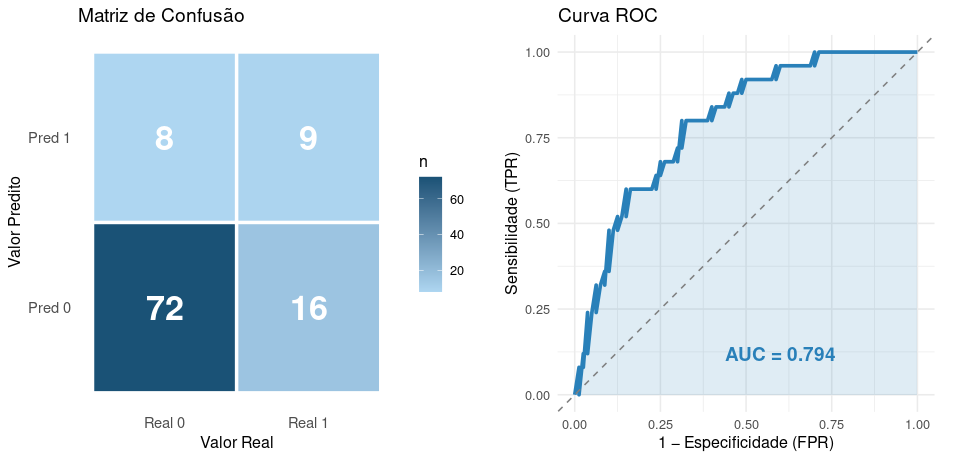

Figura 4. Esquerda: Matriz de Confusão. Direita: Curva ROC com AUC.

```r
# ── Matriz de confusão ──────────────────────────────────────────────────────
cm_df_r <- as.data.frame(cm_r$table)
names(cm_df_r) <- c("Predito", "Real", "N")

p_mc <- ggplot(cm_df_r, aes(x = Real, y = Predito, fill = N)) +
  geom_tile(color = "white", size = 1.2) +
  geom_text(aes(label = N), size = 9, fontface = "bold", color = "white") +
  scale_fill_gradient(low = "#AED6F1", high = "#1A5276") +
  scale_x_discrete(labels = c("0" = "Real 0", "1" = "Real 1")) +
  scale_y_discrete(labels = c("0" = "Pred 0", "1" = "Pred 1")) +
  labs(title = "Matriz de Confusão",
       x = "Valor Real", y = "Valor Predito", fill = "n") +
  theme_minimal(base_size = 12) +
  theme(panel.grid = element_blank(),
        axis.text  = element_text(size = 11))

# ── Curva ROC ───────────────────────────────────────────────────────────────
roc_r   <- roc(teste$y, prob_teste, quiet = TRUE)
auc_r   <- auc(roc_r)
roc_df_r <- data.frame(
  FPR = 1 - roc_r$specificities,
  TPR =     roc_r$sensitivities
)

p_roc <- ggplot(roc_df_r, aes(x = FPR, y = TPR)) +
  geom_ribbon(aes(ymin = 0, ymax = TPR), fill = "#2980B9", alpha = 0.15) +
  geom_line(color = "#2980B9", size = 1.3) +
  geom_abline(slope = 1, intercept = 0,
              linetype = "dashed", color = "gray50") +
  annotate("text", x = 0.60, y = 0.12,
           label = sprintf("AUC = %.3f", auc_r),
           size = 5, color = "#2980B9", fontface = "bold") +
  labs(title = "Curva ROC",
       x = "1 − Especificidade (FPR)",
       y = "Sensibilidade (TPR)") +
  coord_equal() +
  theme_minimal(base_size = 12)

grid.arrange(p_mc, p_roc, ncol = 2)
```

```r
cat(sprintf("\nAUC: %.4f — %s\n", auc_r,
    dplyr::case_when(
      auc_r >= 0.90 ~ "Excelente",
      auc_r >= 0.80 ~ "Bom",
      auc_r >= 0.70 ~ "Aceitável",
      TRUE          ~ "Fraco — revisar o modelo"
    )))
```

```
#>
#> AUC: 0.7945 — Aceitável
```

## 7.11 Previsão para nova observação

```r
# ── Defina aqui a nova observação (um valor por preditora) ──────────────────
valores_novos_r <- c(45, 55)   # altere conforme sua análise
# ────────────────────────────────────────────────────────────────────────────

nova_obs_r <- setNames(
  as.data.frame(t(valores_novos_r)),
  VARIAVEIS_PRED
)

prob_nova_r  <- predict(modelo, newdata = nova_obs_r, type = "response")
classe_nova_r <- ifelse(prob_nova_r >= LIMIAR_DECISAO,
                        "Sucesso (1)", "Fracasso (0)")

for (v in VARIAVEIS_PRED)
  cat(sprintf("%s = %.1f\n", v, nova_obs_r[[v]]))
```

```
#> x1 = 45.0
#> x2 = 55.0
```

```r
cat(sprintf("\nProbabilidade estimada : %.4f\n", prob_nova_r))
```

```
#>
#> Probabilidade estimada : 0.3346
```

```r
cat(sprintf("Classificação (τ = %.2f): %s\n", LIMIAR_DECISAO, classe_nova_r))
```

```
#> Classificação (τ = 0.50): Fracasso (0)
```

# 8. Implementação em Python

> **Como usar:** ajuste as **6 variáveis** do bloco `# CONFIGURAÇÃO` abaixo. O código usa `statsmodels` para inferência completa e `scikit-learn` para métricas de classificação.

## 8.1 Dependências

```python
# Instale com: pip install numpy pandas matplotlib seaborn scikit-learn statsmodels scipy
import os, sys, warnings
import numpy             as np
import pandas            as pd
import matplotlib.pyplot as plt
import matplotlib.gridspec as gridspec
import seaborn           as sns
from scipy  import stats
from sklearn.linear_model    import LogisticRegression
from sklearn.model_selection import train_test_split
from sklearn.metrics         import (
    confusion_matrix, classification_report,
    roc_curve, auc, ConfusionMatrixDisplay, accuracy_score
)
import statsmodels.api as sm

warnings.filterwarnings("ignore")
plt.rcParams.update({"figure.dpi": 130, "font.size": 11})
```

## 8.2 Configuração e importação dos dados

```python
# ════════════════════════════════════════════════════════════
#  CONFIGURAÇÃO — ajuste apenas estas variáveis
# ════════════════════════════════════════════════════════════
CAMINHO_CSV        = "dados.csv"
VARIAVEL_RESPOSTA  = "y"
VARIAVEIS_PRED     = ["x1", "x2"]
LIMIAR_DECISAO     = 0.5
PROPORCAO_TESTE    = 0.30
SEMENTE            = 42
# ════════════════════════════════════════════════════════════

# ── Dados simulados (se o .csv não existir) ─────────────────────────────────
if not os.path.exists(CAMINHO_CSV):
    print(f"Arquivo não encontrado — gerando dados simulados.")
    rng  = np.random.default_rng(SEMENTE)
    n_s  = 350
    x1_s = rng.uniform(18, 65, n_s).round(1)
    x2_s = rng.normal(50, 10, n_s).round(1)
    z_s  = 0.07 * x1_s + 0.06 * x2_s - 7.0
    p_s  = 1 / (1 + np.exp(-z_s))
    y_s  = rng.binomial(1, p_s, n_s)
    pd.DataFrame({"y": y_s, "x1": x1_s, "x2": x2_s}).to_csv(CAMINHO_CSV, index=False)
    print(f"'{CAMINHO_CSV}' criado com {n_s} observações.")

# ── Leitura ──────────────────────────────────────────────────────────────────
raw = pd.read_csv(CAMINHO_CSV)
print(f"Dataset: {raw.shape[0]} linhas × {raw.shape[1]} colunas")
print(f"Colunas: {', '.join(raw.columns)}")

# Validação
cols_faltando = [c for c in [VARIAVEL_RESPOSTA] + VARIAVEIS_PRED
                 if c not in raw.columns]
if cols_faltando:
    sys.exit(f"Colunas ausentes: {', '.join(cols_faltando)}\n"
             "Ajuste VARIAVEL_RESPOSTA e VARIAVEIS_PRED.")

dados = raw[[VARIAVEL_RESPOSTA] + VARIAVEIS_PRED].copy()
dados.rename(columns={VARIAVEL_RESPOSTA: "y"}, inplace=True)
dados["y"] = dados["y"].astype(int)
n_antes = len(dados)
dados.dropna(inplace=True)
if len(dados) < n_antes:
    print(f"Removidas {n_antes - len(dados)} linha(s) com NA.")

N1, N0, N = dados["y"].sum(), (dados["y"] == 0).sum(), len(dados)
print(f"Classe 1: {N1} ({100*N1/N:.1f}%)   Classe 0: {N0} ({100*N0/N:.1f}%)")
```

## 8.3 Análise exploratória

```python
fig = plt.figure(figsize=(13, 4))
gs  = gridspec.GridSpec(1, 1 + len(VARIAVEIS_PRED), figure=fig)

# Dispersão
ax0   = fig.add_subplot(gs[0, 0])
cores = {0: "#C0392B", 1: "#27AE60"}
for cls, grp in dados.groupby("y"):
    ax0.scatter(grp[VARIAVEIS_PRED[0]],
                grp[VARIAVEIS_PRED[1]] if len(VARIAVEIS_PRED) > 1 else grp[VARIAVEIS_PRED[0]],
                c=cores[cls],
                label="Sucesso (1)" if cls == 1 else "Fracasso (0)",
                alpha=0.65, edgecolors="white", s=45)
ax0.set_xlabel(VARIAVEIS_PRED[0]); ax0.set_title("Dispersão por Classe")
ax0.set_ylabel(VARIAVEIS_PRED[1] if len(VARIAVEIS_PRED) > 1 else "")
ax0.legend(fontsize=9)

# Boxplots
for k, var in enumerate(VARIAVEIS_PRED):
    ax = fig.add_subplot(gs[0, k + 1])
    grupos = [dados.loc[dados["y"]==0, var].values,
              dados.loc[dados["y"]==1, var].values]
    bp = ax.boxplot(grupos, patch_artist=True, widths=0.5,
                    medianprops=dict(color="black", linewidth=2))
    for b, cor in zip(bp["boxes"], ["#C0392B", "#27AE60"]):
        b.set_facecolor(cor); b.set_alpha(0.75)
    ax.set_xticklabels(["Fracasso (0)", "Sucesso (1)"], fontsize=9)
    ax.set_title(f"Distribuição de {var}"); ax.set_ylabel(var)

plt.suptitle("Análise Exploratória", fontweight="bold", y=1.01)
plt.tight_layout()
plt.savefig("py_eda.png", bbox_inches="tight"); plt.show()
```

## 8.4 Divisão treino/teste e ajuste do modelo

```python
X = dados[VARIAVEIS_PRED].values
y = dados["y"].values

X_tr, X_te, y_tr, y_te = train_test_split(
    X, y, test_size=PROPORCAO_TESTE,
    random_state=SEMENTE, stratify=y
)
print(f"Treino: {len(y_tr)} obs.  |  Teste: {len(y_te)} obs.")

# ── statsmodels: inferência estatística completa ────────────────────────────
X_tr_sm = sm.add_constant(X_tr)
X_te_sm = sm.add_constant(X_te)
modelo_sm = sm.Logit(y_tr, X_tr_sm).fit(disp=False)
print(modelo_sm.summary())
```

## 8.5 Coeficientes e odds ratios

```python
params  = modelo_sm.params
ep      = modelo_sm.bse
ci      = modelo_sm.conf_int()

nomes = ["Intercepto"] + VARIAVEIS_PRED
df_coef = pd.DataFrame({
    "Coeficiente" : params.values,
    "Erro Padrão" : ep.values,
    "OR"          : np.exp(params.values),
    "IC 2,5% (OR)": np.exp(ci.iloc[:, 0].values),
    "IC 97,5% (OR)":np.exp(ci.iloc[:, 1].values),
    "Valor-p"     : modelo_sm.pvalues.values
}, index=nomes)

print(df_coef.round(4).to_string())
```

## 8.6 Pseudo-R² de McFadden

```python
L_star_py = modelo_sm.llf
N1_tr     = int(y_tr.sum())
N0_tr     = len(y_tr) - N1_tr
N_tr      = len(y_tr)
L0_py     = N1_tr*np.log(N1_tr) + N0_tr*np.log(N0_tr) - N_tr*np.log(N_tr)

r2_mcf_py = -L_star_py / L0_py
print(f"L* = {L_star_py:.4f}   L0 = {L0_py:.4f}")
print(f"Pseudo-R² de McFadden: {r2_mcf_py:.4f}")
print(f"(statsmodels nativo):   {modelo_sm.prsquared:.4f}")

avaliacao = ("Fraco"       if r2_mcf_py < 0.20 else
             "Bom"         if r2_mcf_py < 0.40 else
             "Muito bom")
print(f"Avaliação: {avaliacao}")
```

## 8.7 Teste da razão de verossimilhanças

```python
modelo_nulo_py = sm.Logit(y_tr, np.ones(N_tr)).fit(disp=False)
G_py     = 2 * (modelo_sm.llf - modelo_nulo_py.llf)
gl_py    = len(VARIAVEIS_PRED)
pval_py  = 1 - stats.chi2.cdf(G_py, df=gl_py)

print(f"H0: todos os coeficientes = 0")
print(f"Estatística G:      {G_py:.4f}")
print(f"Graus de liberdade: {gl_py}")
print(f"Valor-p:            {pval_py:.2e}")
print("Decisão:", "Rejeitar H0." if pval_py < 0.05 else "Não rejeitar H0.")
```

## 8.8 Teste de Wald

```python
w_py  = (params / ep) ** 2
pw_py = 1 - stats.chi2.cdf(w_py, df=1)

df_wald = pd.DataFrame({
    "Coeficiente"  : params.values.round(4),
    "Erro Padrão"  : ep.values.round(4),
    "Estatística W": w_py.values.round(4),
    "Valor-p"      : pw_py.values.round(6),
    "Decisão"      : ["Rejeitar H0 (*)" if p < 0.05 else "Não rejeitar H0"
                      for p in pw_py]
}, index=nomes)

print("H0: a_i = 0  |  H1: a_i ≠ 0\n")
print(df_wald.to_string())
```

## 8.9 Previsão e avaliação no conjunto de teste

```python
# scikit-learn para previsão e métricas de classificação
modelo_sk = LogisticRegression(max_iter=1000, random_state=SEMENTE)
modelo_sk.fit(X_tr, y_tr)

prob_te   = modelo_sk.predict_proba(X_te)[:, 1]
y_pred_py = (prob_te >= LIMIAR_DECISAO).astype(int)

acc_py  = accuracy_score(y_te, y_pred_py)
err_py  = 1 - acc_py
print(f"Acurácia:     {acc_py:.4f}  ({100*acc_py:.1f}%)")
print(f"Taxa de erro: {err_py:.4f}  ({100*err_py:.1f}%)\n")
print(classification_report(y_te, y_pred_py,
                             target_names=["Fracasso (0)", "Sucesso (1)"]))
```

## 8.10 Visualizações: matriz de confusão e curva ROC

```python
cm_py = confusion_matrix(y_te, y_pred_py)
VN, FP, FN, VP = cm_py.ravel()
sens = VP / (VP + FN) if (VP + FN) > 0 else 0
spec = VN / (VN + FP) if (VN + FP) > 0 else 0
prec = VP / (VP + FP) if (VP + FP) > 0 else 0
f1   = 2*prec*sens / (prec+sens) if (prec+sens) > 0 else 0

print(f"Sensibilidade: {sens:.4f}  Especificidade: {spec:.4f}")
print(f"Precisão:      {prec:.4f}  F1-Score:       {f1:.4f}")

fig, axes = plt.subplots(1, 2, figsize=(11, 4.5))

# Matriz de confusão
ConfusionMatrixDisplay(cm_py,
    display_labels=["Fracasso (0)", "Sucesso (1)"]).plot(
    ax=axes[0], colorbar=False, cmap="Blues")
axes[0].set_title(f"Matriz de Confusão\nAcurácia = {acc_py:.3f}")

# Curva ROC
fpr_py, tpr_py, _ = roc_curve(y_te, prob_te)
auc_py            = auc(fpr_py, tpr_py)
axes[1].fill_between(fpr_py, tpr_py, alpha=0.15, color="#2980B9")
axes[1].plot(fpr_py, tpr_py, color="#2980B9", lw=2,
             label=f"AUC = {auc_py:.3f}")
axes[1].plot([0,1],[0,1],"k--", lw=1, label="Aleatório")
axes[1].set_xlabel("1 − Especificidade"); axes[1].set_ylabel("Sensibilidade")
axes[1].set_title("Curva ROC"); axes[1].legend(loc="lower right")
axes[1].set_aspect("equal")

plt.tight_layout()
plt.savefig("py_mc_roc.png", bbox_inches="tight"); plt.show()
print(f"\nAUC: {auc_py:.4f}")
```

## 8.11 Previsão para nova observação

```python
# ── Defina aqui a nova observação (um valor por preditora) ──────────────────
valores_novos_py = [45, 55]
# ────────────────────────────────────────────────────────────────────────────

nova_obs_py  = np.array(valores_novos_py).reshape(1, -1)
prob_nova_py = modelo_sk.predict_proba(nova_obs_py)[0, 1]
classe_nova  = "Sucesso (1)" if prob_nova_py >= LIMIAR_DECISAO else "Fracasso (0)"

for var, val in zip(VARIAVEIS_PRED, valores_novos_py):
    print(f"{var} = {val}")
print(f"\nProbabilidade estimada: {prob_nova_py:.4f}")
print(f"Classificação (τ = {LIMIAR_DECISAO}): {classe_nova}")
```

# 9. Comparativo R vs Python

| Etapa | R | Python |
| --- | --- | --- |
| Ajuste do modelo | `glm(..., family = binomial)` | `sm.Logit().fit()` |
| Coeficientes | `coef(modelo)` | `modelo.params` |
| Intervalos de confiança | `confint(modelo)` | `modelo.conf_int()` |
| Odds Ratios | `exp(coef(modelo))` | `np.exp(modelo.params)` |
| Pseudo-R² | `DescTools::PseudoR2()` | `modelo.prsquared` |
| TRV global | `anova(nulo, modelo, test="Chisq")` | `2*(modelo.llf - nulo.llf)` → `chi2.cdf` |
| Teste de Wald | `summary(modelo)` (z value) | `modelo.tvalues`² |
| Probabilidade predita | `predict(modelo, type="response")` | `modelo.predict(X_sm)` |
| Matriz de confusão | `caret::confusionMatrix()` | `sklearn.metrics.confusion_matrix` |
| Curva ROC | `pROC::roc()` + `auc()` | `sklearn.metrics.roc_curve` + `auc()` |

# 10. Checklist da Análise Completa

```
#>   [✓] Importação e validação do arquivo .csv
#>   [✓] Análise exploratória: dispersão e boxplots por classe
#>   [✓] Balanceamento de classes verificado
#>   [✓] Divisão estratificada treino/teste
#>   [✓] Ajuste do modelo logístico por Máxima Verossimilhança
#>   [✓] Coeficientes, erros-padrão e odds ratios com IC 95%
#>   [✓] Pseudo-R² de McFadden calculado e interpretado
#>   [✓] Teste da Razão de Verossimilhanças (significância global)
#>   [✓] Teste de Wald (significância individual de cada coeficiente)
#>   [✓] Acurácia e taxa de erro no conjunto de teste
#>   [✓] Matriz de confusão com sensibilidade, especificidade, F1
#>   [✓] Curva ROC e AUC calculadas e interpretadas
#>   [✓] Previsão para nova observação realizada
```

# 11. Referências

- **Hosmer, D. W., Lemeshow, S., & Sturdivant, R. X.** (2013). *Applied Logistic Regression* (3ª ed.). Wiley.
- **McFadden, D.** (1974). Conditional logit analysis of qualitative choice behavior. In P. Zarembka (Ed.), *Frontiers in Econometrics* (pp. 105–142). Academic Press.
- **James, G., Witten, D., Hastie, T., & Tibshirani, R.** (2021). *An Introduction to Statistical Learning with Applications in R* (2ª ed.). Springer. Disponível em: https://www.statlearning.com
- **McCullagh, P., & Nelder, J. A.** (1989). *Generalized Linear Models* (2ª ed.). Chapman & Hall/CRC.
- **Pedregosa, F. et al.** (2011). Scikit-learn: Machine Learning in Python. *Journal of Machine Learning Research*, 12, 2825–2830.
- **Seabold, S., & Perktold, J.** (2010). Statsmodels: Econometric and Statistical Modeling with Python. *Proceedings of the 9th Python in Science Conference*.

*Tutorial produzido com base nas notas de aula de análise de regressão logística binária, revisadas, formalizadas e expandidas com conteúdos complementares e implementações completas em R e Python.*